# Influence d’élus régionaux écologistes sur l’agriculture durable

Est-ce que l’élection de représentants politiques à tendance écologique influence réellement la surface en agriculture biologique ou encore le nombre d’exploitation certifiée HVE ?

Author

Lydie DEHOVE et Margot MARTIN

Published

February 5, 2026

## I- Introduction

Dans un contexte de prochaines élections européennes, la population va être amenée à se questionner sur les valeurs qu’elle souhaite porter en désignant un candidat. Nous pouvons aisément supposer qu’une grande partie de la population souhaitera élire un député européen ayant dans son programme politique quelques considérations sur l’environnement et ainsi espérer que des politiques publiques seront mises en place afin, dans notre cas présent, d’aider au développement d’une agriculture plus durable. **Mais pour autant, est-ce que l’élections de représentants politique à tendance écologique influence réellement la surface en agriculture biologique ou encore le nombre d’exploitation certifiée HVE ?**

### Le choix des données

- **Description du mode de scrutin des élections régionales**

Pour mener à bien cette étude nous avions besoin de représentants avec un ancrage local qui pouvaient directement influencer la conduite de politique sur son territoire. Ainsi travailler à partir des résultats aux élections régionales de 2021 semble être le choix le plus cohérent ; le conseiller régional possédant un relativement grand pouvoir d’influence sur les politiques qui sont menées dans sa région.

Les conseillers régionaux sont élus pour une durée de 6 ans et lorsqu’une liste atteint la majorité des voix elle obtient le quart des sièges, les autres sièges étant répartis proportionnellement aux suffrages exprimés pour chaque liste. Les effectifs des conseils régionaux varient de 209 à 41 sièges par région.

```r
library(knitr)
#définition de l'espace de travail
path<-"/Users/margo/Documents/Margot/CPES-H4/CPES-2/Econométrie/Mémoire-recherche/Bases-données/"
#Tableau représantant l'effectif du conseil pour chaque région
eff_conseil_reg<-read.csv(paste0(path,"data-uBsEd.csv"))

kable(eff_conseil_reg)
```

| Région | Effectif.du.conseil.régional |
| --- | --- |
| Alsace, Champagne-Ardenne et Lorraine | 169 |
| Aquitaine, Limousin et Poitou-Charentes | 183 |
| Auvergne et Rhône-Alpes | 204 |
| Bourgogne et Franche-Comté | 100 |
| Bretagne | 83 |
| Centre | 77 |
| Guadeloupe | 41 |
| Île-de-France | 209 |
| Languedoc-Roussillon et Midi-Pyrénées | 158 |
| Nord - Pas-de-Calais et Picardie | 170 |
| Basse-Normandie et Haute-Normandie | 102 |
| Pays de la Loire | 93 |
| Provence-Alpes-Côte d’Azur | 123 |
| La Réunion | 45 |

- **Choix des indicateurs de mesure d’une agriculture durable**

Pour ce qu’il en est des indicateurs nous permettant de mesurer le développement d’une agriculture plus durable, la certification Agriculture Biologique, qui assure une production sans OGM et restreint l’utilisation de produits chimiques de synthèse, apparaît comme pertinente.

De même la certification HVE signifiant Haute Valeur Environnementale permet d’attester un engagement de l’exploitation agricole dans une démarche de progrès de leurs pratiques en matière de respect de la biodiversité, de stratégies phytosanitaires, de gestion de la fertilisation des sols ou encore de la gestion des ressources en eau.

Le nombre d’exploitations certifiées AB ainsi que certifiées HVE seront donc les indicateurs à partir desquels nous mesurerons la mise en place de politiques publiques plus durables dans la région.

### Littérature académique existante

Dans *Quand l’alimentation se fait politique(s)*, Léa Sénégas dédie un chapitre entier à la différenciation des politiques régionales vis-à-vis de l’agriculture biologique. Au début des années 1990, les premiers plans de soutien à l’agriculture biologique apparaissent en France, et dès le début les régions sont particulièrement impliquées dans la politique nationale. Elle y compare notamment la gestion de la question en Bretagne, dans l’ancienne région Auvergne et dans la nouvelle région Auvergne-Rhône-Alpes entre 2014 et 2017. On remarque par exemple que la majorité PS en Bretagne soutient l’agriculture biologique au travers de différentes actions et qu’elle s’était engagée à doubler le nombre d’exploitations biologiques sur le territoire. Aussi, en 2011, la région Bretagne a lancé le dispositif Pass Bio pour soutenir la conversion et le suivi des agriculteurs vers l’agriculture biologique.

De même en Auvergne le président de la région, PS lui aussi, souhaitait élaborer une politique de soutien à l’agriculture biologique en s’appuyant sur la représentation autonome de la filière. De plus, la communication sur les labels de qualité envers les consommateurs était une priorité de la politique de la région. L’approvisionnement des lycées en fruits et légumes bio a aussi favorisé l’agriculture biologique.

Au contraire, depuis la création de la nouvelle région AuRA avec une majorité LR à sa tête, les élus ont affiché leur volonté d’orienter la politique agricole quasi-exclusivement en direction des agriculteurs en augmentant les subventions d’investissements au bâti ou au matériel agricole favorisant les plus grosses structures au détriment des exploitations biologique souvent de petite taille. Cela constitue une rupture avec l’ancienne politique de la région Auvergne.

Il apparaît donc clairement dans cet article qu’un même territoire est amené à être organisé et financé différemment en fonction de la majorité régionale. Cela entraîne ou non un développement de l’agriculture biologique dans ce territoire.

Aussi, une limite peut être soulevée : celle de la capacité d’initiative des régions dans la mise en place de politiques d’aides pour une agriculture plus durable. En effet, comme le souligne Sabine Girard et Pierre Antoine Landel dans « Du développement durable à la transition écologique : gouverner le changement territorial » (*Géographie, Economie et Société*, 2023) les pouvoirs locaux n’ont pas beaucoup de moyens pour inciter les agriculteurs à se certifier bio. Les politiques agricoles et leurs subventions sont décidées au niveau national voir supranational lorsqu’on prend l’exemple de la PAC. Ainsi les régions, ne pouvant subventionner les efforts faits par les agriculteurs, on pourrait penser qu’elles ont un faible impact sur le nombre réel de certification.

Finalement comme l’a montré Léa Sénégas, le pouvoir des régions d’imprimer des politiques publiques ne dépend pas que des subventions. Elles peuvent tout de même agir avec par exemple un accroissement de la communication faite autour des labels ou encore l’imposition d’un repas bio par semaine dans les cantines scolaires permettant de créer des débouchés valorisés pour les produits agricoles certifiés et ainsi développer ce modèle d’agriculture.

Toujours est-il que l’impact des décideurs régionaux sur le développement d’une agriculture plus durable reste à quantifier.

## II- Nettoyage de données

Afin de répondre à notre objectif de quantification, nous avons utilisé principalement 3 bases de données.

```r
#Importer les packages nécessaires
library(sf)
library(ggplot2)
library(maps)
library(readxl)
library(dplyr)
library(tidyverse)
library(stringr)
library(viridis)
library(knitr)
library(DT)
library(bslib)
library(cowplot)
library(stargazer)
library(gridExtra)
```

1. **Surface agricole biologique**

La première recense les surfaces bio en hectares par communes et par type de culture. Ces données sont issues des contrôles annuels que les organismes certificateurs agréés réalisent dans les fermes engagées en bio et proviennent de Agence Bio.

```r
#Importer la première base de données
bio<- read_excel(paste0(path,"donnees-communales-surfaces-cheptels-2019-2022-agencebio.xlsx"), sheet="Surfaces")

#Tableau des données
kable(bio[1:5,])
```

| annee | codecommune | libellecommune | com_code_postal | canton | arrondissement | codeepci | libelleepci | codedepartement | libelledepartement | coderegion | libelleregion | code_groupe | nb_exp | surfab | surfc1 | surfc2 | surfc3 | surfc123 | surfbio |
| --- | --- | --- | --- | --- | --- | --- | --- | --- | --- | --- | --- | --- | --- | --- | --- | --- | --- | --- | --- |
| 2019 | 01002 | L’ABERGEMENT-DE-VAREY | 01640 | 0101 | 011 | 240100883 | CC de la Plaine de l’Ain | 01 | Ain | 84 | Auvergne-Rhône-Alpes | AU | 1 | 0.00 | 0.00 | 0.19 | 0 | 0.19 | 0.19 |
| 2019 | 01002 | L’ABERGEMENT-DE-VAREY | 01640 | 0101 | 011 | 240100883 | CC de la Plaine de l’Ain | 01 | Ain | 84 | Auvergne-Rhône-Alpes | GCU | 1 | 18.85 | 5.78 | 0.00 | 0 | 5.78 | 24.63 |
| 2019 | 01002 | L’ABERGEMENT-DE-VAREY | 01640 | 0101 | 011 | 240100883 | CC de la Plaine de l’Ain | 01 | Ain | 84 | Auvergne-Rhône-Alpes | HSAU | 1 | 0.12 | 0.00 | 0.00 | 0 | 0.00 | 0.12 |
| 2019 | 01002 | L’ABERGEMENT-DE-VAREY | 01640 | 0101 | 011 | 240100883 | CC de la Plaine de l’Ain | 01 | Ain | 84 | Auvergne-Rhône-Alpes | SF | 2 | 24.95 | 1.20 | 0.00 | 0 | 1.20 | 26.15 |
| 2019 | 01004 | AMBÉRIEU-EN-BUGEY | 01500 | 0101 | 011 | 240100883 | CC de la Plaine de l’Ain | 01 | Ain | 84 | Auvergne-Rhône-Alpes | AU | 1 | 7.10 | 0.00 | 0.00 | 0 | 0.00 | 7.10 |

2. **Nombre d’exploitations HVE**

Notre seconde base de données est un répertoire des exploitations agricoles possédant la certification HVE. Ce répertoire est mis à jour tous les 6 mois ; la dernière ayant été faite le 1er juillet 2023. Les données ont été produites par le ministère de l’agriculture et de l’alimentation et nous les avons récupérées sur data.gouv.

```r
#Importer la deuxième base de données
hve<-read_excel(paste0(path,"annuaire-hve-au-01-07-2023.xlsx"), sheet="Liste des exploitation HVE", skip=4)

kable(hve[1:5,])
```

| Nom ou Raison sociale | Adresse | Code Postal | Région | Département | Commune | Site internet | Activité principale | Activité principale2 | Vente directe | Date de certification |
| --- | --- | --- | --- | --- | --- | --- | --- | --- | --- | --- |
| EI MOLLIERE LUC | 88 CHEMIN DE COURS | 38590 | AUVERGNE-RHÔNE-ALPES | ISÈRE | SAINT ETIENNE DE SAINT GEOIRS | NA | NA | GRANDES CULTURES : CÉRÉALES, OLÉAGINEUX, PROTÉAGINEUX, AUTRES | NON | 20/06/2022 |
| GERARD MICHALLET | 59 ROUTE DE CHARPENAY | 69490 | AUVERGNE-RHÔNE-ALPES | RHÔNE | SAINT ROMAIN DE POPEY | NA | NA | VITICULTURE | NON | 30/04/2021 |
| CEBE PATRICE | 2 BOULEVARD LOUIS PASTEUR | 34290 | OCCITANIE | HÉRAULT | ABEILHAN | NA | NA | VITICULTURE | NON | 03/08/2022 |
| FIS JEAN-GABRIEL | 11 BOULEVARD PASTEUR | 34290 | OCCITANIE | HÉRAULT | ABEILHAN | NA | NA | VITICULTURE | NON | 03/08/2022 |
| ORCIERE MARC | 9 RUE DENIS PAPIN | 34290 | OCCITANIE | HÉRAULT | ABEILHAN | NA | NA | VITICULTURE | NON | 03/08/2022 |

Pour ce qu’il en est des variables, celle qui nous intéressera sera celle du nombre d’exploitation HVE par régions.

Nous importons aussi deux petites bases de données complémentaires qui nous permettrons de normaliser nos valeurs de surface biologiques et le nombre d’exploitation agricole qui varient selon les régions afin de neutraliser l’effet de nombre qui pourrait avoir lorsqu’une région est plus grande en superficie et donc dispose de plus de surface agricole.

```r
#Importer les bases de données contenant la surface agricole totale par région
SAU_région<-read_excel(paste0(path,"SAU-région-.xlsx"),skip=4)

kable(SAU_région, col.names=c("codgeo", "libegeo", "an", "Surface agricole en hectare"))
```

| codgeo | libegeo | an | Surface agricole en hectare |
| --- | --- | --- | --- |
| 01 | Guadeloupe | 2020 | 31836 |
| 02 | Martinique | 2020 | 21895 |
| 03 | Guyane | 2020 | 36244 |
| 04 | La Réunion | 2020 | 38773 |
| 06 | Mayotte | 2020 | 5960 |
| 11 | Île-de-France | 2020 | 564029 |
| 24 | Centre-Val de Loire | 2020 | 2284646 |
| 27 | Bourgogne-Franche-Comté | 2020 | 2428469 |
| 28 | Normandie | 2020 | 1952877 |
| 32 | Hauts-de-France | 2020 | 2128620 |
| 44 | Grand Est | 2020 | 3024723 |
| 52 | Pays de la Loire | 2020 | 2079343 |
| 53 | Bretagne | 2020 | 1624259 |
| 75 | Nouvelle-Aquitaine | 2020 | 3871624 |
| 76 | Occitanie | 2020 | 3131236 |
| 84 | Auvergne-Rhône-Alpes | 2020 | 2860396 |
| 93 | Provence-Alpes-Côte d’Azur | 2020 | 628468 |
| 94 | Corse | 2020 | 167093 |

```r
#Importer les bases de données contenant le nombre total d'exploitation agricole par région
exp_région<-read_excel(paste0(path,"nb_exp-région.xlsx"),skip=4)

kable(exp_région, col.names = c("codgeo", "libegeo", "an", "Nombre d'exploitation agricole"))
```

| codgeo | libegeo | an | Nombre d’exploitation agricole |
| --- | --- | --- | --- |
| 01 | Guadeloupe | 2020 | 7254 |
| 02 | Martinique | 2020 | 2679 |
| 03 | Guyane | 2020 | 6130 |
| 04 | La Réunion | 2020 | 6282 |
| 06 | Mayotte | 2020 | 4312 |
| 11 | Île-de-France | 2020 | 4425 |
| 24 | Centre-Val de Loire | 2020 | 19919 |
| 27 | Bourgogne-Franche-Comté | 2020 | 23662 |
| 28 | Normandie | 2020 | 26510 |
| 32 | Hauts-de-France | 2020 | 23463 |
| 44 | Grand Est | 2020 | 40989 |
| 52 | Pays de la Loire | 2020 | 26409 |
| 53 | Bretagne | 2020 | 26347 |
| 75 | Nouvelle-Aquitaine | 2020 | 64189 |
| 76 | Occitanie | 2020 | 64370 |
| 84 | Auvergne-Rhône-Alpes | 2020 | 48493 |
| 93 | Provence-Alpes-Côte d’Azur | 2020 | 18056 |
| 94 | Corse | 2020 | 2936 |

3. **Résultats aux élections régionales de 2021**

Notre troisième base de données regroupe les résultats des élections des conseillers régionaux élus au deuxième tour en 2021. Elle est issue du site du gouvernement data.gouv.

```r
#Importer la troisième base de données
election<-read.csv(paste0(path,"election_region2021.csv"),sep = ";")

#Afficher le nom de chaque variable
kable(election[1:5,])
```

| Code.de.la.région | Libellé.de.la.région | Inscrits | Abstentions | X..Abs.Ins | Votants | X..Vot.Ins | Blancs | X..Blancs.Ins | X..Blancs.Vot | Nuls | X..Nuls.Ins | X..Nuls.Vot | Exprimés | X..Exp.Ins | X..Exp.Vot | N.Liste | Nuance.Liste | Libellé.Abrégé.Liste | Libellé.Etendu.Liste | Nom.Tête.de.Liste | Voix | X..Voix.Ins | X..Voix.Exp | Sièges | X | X.1 | X.2 | X.3 | X.4 | … |
| --- | --- | --- | --- | --- | --- | --- | --- | --- | --- | --- | --- | --- | --- | --- | --- | --- | --- | --- | --- | --- | --- | --- | --- | --- | --- | --- | --- | --- | --- | --- |
| 44 | Grand Est | 3831079 | 2672636 | 69,76 | 1158443 | 30,24 | 32948 | 0,86 | 2,84 | 20890 | 0,55 | 1,8 | 1104605 | 28,83 | 95,35 | 2 | LDVC | FORCE TERRITOIRES | La force de nos territoires | KLINKERT Brigitte | 134414 | 3,51 | 12,17 | 15 | 5 | LRN | RASSEMBLEMENT ACAL | RASSEMBLEMENT POUR L’ALSACE, LA CHAMPAGNE-ARDENNE ET LA LORRAINE | JACOBELLI Laurent | … |
| 75 | Nouvelle-Aquitaine | 4352880 | 2760872 | 63,43 | 1592008 | 36,57 | 42396 | 0,97 | 2,66 | 35641 | 0,82 | 2,24 | 1513971 | 34,78 | 95,1 | 1 | LRN | URSF-RN | Une région au service de la France liste soutenue par le Rassemblement National | DIAZ Edwige | 289258 | 6,65 | 19,11 | 26 | 2 | LUG | NTNE-AR | Nos Territoires nos énergies avec Alain Rousset | ROUSSET Alain | … |
| 84 | Auvergne-Rhône-Alpes | 5405165 | 3602658 | 66,65 | 1802507 | 33,35 | 41392 | 0,77 | 2,3 | 20502 | 0,38 | 1,14 | 1740613 | 32,2 | 96,57 | 2 | LUG | ENSEMBLE, L’ÉCOLOGIE C’ES | Ensemble, l’écologie c’est possible! Avec Fabienne GREBERT | GREBERT Fabienne | 585039 | 10,82 | 33,61 | 51 | 6 | LUD | LAURENT WAUQUIEZ - LA RÉG | Laurent Wauquiez - La Région avec toutes ses forces | WAUQUIEZ Laurent | … |
| 27 | Bourgogne-Franche-Comté | 1967131 | 1248387 | 63,46 | 718744 | 36,54 | 20109 | 1,02 | 2,8 | 11680 | 0,59 | 1,63 | 686955 | 34,92 | 95,58 | 2 | LRN | POUR UNE REGION QUI VOUS | POUR UNE REGION QUI VOUS PROTEGE Liste soutenue par le Rassemblement National | ODOUL Julien | 163363 | 8,3 | 23,78 | 18 | 4 | LREM | LA REGION PARTOUT ET POUR | La Région partout et pour tous - Majorité présidentielle | THURIOT Denis | … |
| 53 | Bretagne | 2495250 | 1581386 | 63,38 | 913864 | 36,62 | 20771 | 0,83 | 2,27 | 18825 | 0,75 | 2,06 | 874268 | 35,04 | 95,67 | 1 | LLR | HISSONS HAUT LA BRETAGNE | HISSONS HAUT LA BRETAGNE | LE CALLENNEC Isabelle | 192127 | 7,7 | 21,98 | 14 | 2 | LUGE | BRETAGNE D’AVENIR | BRETAGNE D’AVENIR | DESMARES-POIRRIER Claire | … |

Voici une rapide présentation des variables : sur chaque ligne, on trouve l’une des 18 régions françaises, identifiée par son nom ainsi que des données descriptives des résultats des élections avec par exemple le nombre de personnes inscrites, le nombre d’abstentionnistes, le nombre de votes blancs, … Mais surtout la nuance de la liste qui nous permet sélectionner les listes regroupées sous le nuançage écologiste identifiées par la modalité LECO. Nous avons également le nombre de voix pour cette liste ainsi que le nombre de sièges obtenus par la liste.

Nous avons ensuite supprimé des bases de données les variables qui n’allaient pas nous être utiles.

```r
#cleaning database bio
bio<-bio%>%
  filter(annee==2022) %>% #on se concentre sur le dernier rescenscement
  group_by(libelleregion) %>% #notre étude porte sur une échelle régionale
  select(-annee)%>%
  summarise(
    coderegion = first(coderegion),
    libelleregion = first(libelleregion),
    nb_exp=sum(as.numeric(nb_exp)),
    surfc1=round(sum(surfc1),2), #on ne garde que les parcelles bio qui sont en première année et deuxième année de conversion pour étudier l'impact de l'élection en 2021
    surfc2=round(sum(surfc2),2),
    surfbio=round(sum(surfc2+surfc1),2))

#Cleaning database hve
hve<-hve%>%
  #suppression des variables inutilisées
  select(-`Site internet`, -`Activité principale`, -`Vente directe`) %>%
  mutate(annee=as.numeric(substr(`Date de certification`,7,10))) %>%
  filter(annee>=2021) %>%
  mutate(nb_exploitation_HVE=1) %>%
  group_by(Région)%>%
  summarise(
    Région=first(Région),
    #on compte le nombre d'exploitation certifiées HVE par région
    nb_exploitation_HVE=sum(nb_exploitation_HVE))

#Cleaning database election
##On réorganise la base de données pour avoir une liste électorale par ligne
n_var_region<-16
n_var_liste<-9

n_blocs<-(ncol(election)-n_var_region)/n_var_liste

dt_long<-election[,1:(n_var_region + n_var_liste)]

for (i in 1:(n_blocs - 1)){

  col_min<-n_var_region+1+(i*n_var_liste)
  col_max<-n_var_region+((i+1)*n_var_liste)

  dt_temp<-election[,c(1:n_var_region, col_min:col_max)]
  names(dt_temp)<-names(dt_long)
  dt_temp<-dt_temp[!is.na(dt_temp$Voix),]

  dt_long<-rbind(dt_long, dt_temp)

}

#On ne garde uniquement les variables qui nous intéressent
election<-dt_long %>%
  select(Code.de.la.région, Libellé.de.la.région,  Nuance.Liste,Libellé.Abrégé.Liste,Voix, Sièges)
```

Après avoir sélectionné les variables qui nous intéressent, nous avons agrégées les 3 bases de données par région.

```r
#On transforme donc les noms de la variable région pour les normaliser
hve$Région<-str_to_lower(hve$Région)
bio$libelleregion<-str_to_lower(bio$libelleregion)
election$Libellé.de.la.région<-str_to_lower(election$Libellé.de.la.région)

hve$Région[hve$Région=="ile-de-france"]<-"île-de-france" #on renomme l'île de france pour une fusion parfaite

#on rassemble les résultats des élections par région en ne gardant que les listes écologiques
election<-election%>%
  group_by(Libellé.de.la.région)%>%
  mutate(propor_siège=sum(Sièges[Nuance.Liste %in% c("LUGE", "LECO")|Libellé.Abrégé.Liste %in% c("ENSEMBLE, L'ÉCOLOGIE C'ES")]) / sum(Sièges) * 100,
         propor_voix=sum(Voix[Nuance.Liste %in% c("LUGE", "LECO")|Libellé.Abrégé.Liste %in% c("ENSEMBLE, L'ÉCOLOGIE C'ES")])/ sum(Voix) * 100) %>%
  distinct(Libellé.de.la.région, .keep_all = T)

#fusion des différentes bases de données
merged_hve_bio<-full_join(hve, bio, by = c("Région" = "libelleregion"))
merged_data_election<-full_join(merged_hve_bio, election, by = c("Région" = "Libellé.de.la.région"))
merged_data_normal<-full_join(SAU_région, exp_région, by = c("codgeo" = "codgeo"))
#l'ensemble de nos données seront rassemblées dans la base de données merged_data et nous travaillerons à partir de celle-ci
merged_data<-full_join(merged_data_election,merged_data_normal, by=c("coderegion"="codgeo"))

#recodage des variables du tableau final
merged_data<-merged_data%>%
  select(-Région,-libgeo.y,-an.y,-an.x,-Libellé.Abrégé.Liste, -Code.de.la.région, -Nuance.Liste)%>%
  rename(nb_exp_bio=nb_exp,
         nb_exp_hve=nb_exploitation_HVE,
        region=libgeo.x)%>%
  relocate(region, .before=nb_exp_hve)%>%
  #création de variables qui normalisent nos variables
  mutate(nb_exp_hve_ratio=nb_exp_hve/exp2020*100, #on rapporte le nombre d'exploitations certifiées hve par région par rapport au nombre total d'exploitations agricoles de la région
         surfbio_sau_ratio=surfbio/sau2020*100,
         nb_exp_bio_ratio=nb_exp_bio/exp2020*100)
```

## III- Statistiques descriptives

Penchons-nous sur quelques statistiques descriptives afin de mieux appréhender notre base de données. Tout d’abord, nous avons cherché à comparer les exploitations HVE et celles certifiées bio.

```r
#calcul du nombre total d'exploitations certifiées HVE
nbtotal_hve<-sum(merged_data$nb_exp_hve, na.rm=T)

stats_bio_hve<-merged_data%>%
  group_by(region)%>%
  summarise(
    moyenne_surf_bio=first(surfbio),
    pourcent_surf_bio=(surfbio/sau2020*100),#pourcentage de surface bio par rapport à la surface agricole totale
    moyenne_exp_bio=mean(nb_exp_bio),
    pourcent_exp_bio=(nb_exp_bio/exp2020*100), #pourcentage d'exploitation bio par rapport au nombre total d'exploitation
    moyenne_exp_hve=mean(nb_exp_hve, na.rm=T),
    pourcent_exp_hve=(nb_exp_hve/exp2020*100),#pourcentage d'exploitation hve par rapport au nombre total d'exploitation
    proportion_hve=(nb_exp_hve/nbtotal_hve*100))#pourcentage d'exploitation certifiées hve dans la région par rapport au nombre total en france

kable(stats_bio_hve)
```

| region | moyenne_surf_bio | pourcent_surf_bio | moyenne_exp_bio | pourcent_exp_bio | moyenne_exp_hve | pourcent_exp_hve | proportion_hve |
| --- | --- | --- | --- | --- | --- | --- | --- |
| Auvergne-Rhône-Alpes | 37896.51 | 1.3248694 | 19874 | 40.983235 | 1732 | 3.5716495 | 11.1973106 |
| Bourgogne-Franche-Comté | 33778.28 | 1.3909290 | 7780 | 32.879723 | 413 | 1.7454146 | 2.6700284 |
| Bretagne | 18494.61 | 1.1386491 | 9576 | 36.345694 | 333 | 1.2639010 | 2.1528317 |
| Centre-Val de Loire | 19501.74 | 0.8536001 | 4766 | 23.926904 | 416 | 2.0884583 | 2.6894233 |
| Corse | 9372.19 | 5.6089663 | 1280 | 43.596730 | 73 | 2.4863760 | 0.4719421 |
| Grand Est | 33595.57 | 1.1106991 | 8976 | 21.898558 | 2682 | 6.5432189 | 17.3390225 |
| Guadeloupe | 452.36 | 1.4209071 | 497 | 6.851392 | 1 | 0.0137855 | 0.0064650 |
| Guyane | 268.45 | 0.7406743 | 279 | 4.551387 | NaN | NA | NA |
| Hauts-de-France | 9435.41 | 0.4432642 | 3455 | 14.725312 | 340 | 1.4490901 | 2.1980864 |
| La Réunion | 382.35 | 0.9861244 | 975 | 15.520535 | 10 | 0.1591850 | 0.0646496 |
| Martinique | 165.55 | 0.7561087 | 326 | 12.168720 | 12 | 0.4479283 | 0.0775795 |
| Mayotte | 138.72 | 2.3275168 | 78 | 1.808905 | NaN | NA | NA |
| Normandie | 17244.35 | 0.8830228 | 5167 | 19.490758 | 192 | 0.7242550 | 1.2412723 |
| Nouvelle-Aquitaine | 61001.37 | 1.5756016 | 20960 | 32.653570 | 3520 | 5.4838056 | 22.7566589 |
| Occitanie | 104972.25 | 3.3524222 | 32516 | 50.514215 | 3498 | 5.4342085 | 22.6144298 |
| Pays de la Loire | 29236.79 | 1.4060590 | 10337 | 39.141959 | 509 | 1.9273732 | 3.2906646 |
| Provence-Alpes-Côte d’Azur | 38338.18 | 6.1002597 | 12176 | 67.434648 | 1684 | 9.3265397 | 10.8869925 |
| Île-de-France | 6735.55 | 1.1941851 | 1677 | 37.898305 | 53 | 1.1977401 | 0.3426429 |

Il en est de même pour le pourcentage d’exploitations certifiées HVE où c’est encore la région PACA qui en possède le plus, avec 9% de ses exploitations certifiées HVE.

Cela nous permet d’émettre l’hypothèse d’un corrélation entre nos 2 indicateurs d’une agriculture durable. La régression suivante ainsi que la distribution du nombre d’exploitation HVE et AB dans chaque région nous permettent d’affirmer cette corrélation.

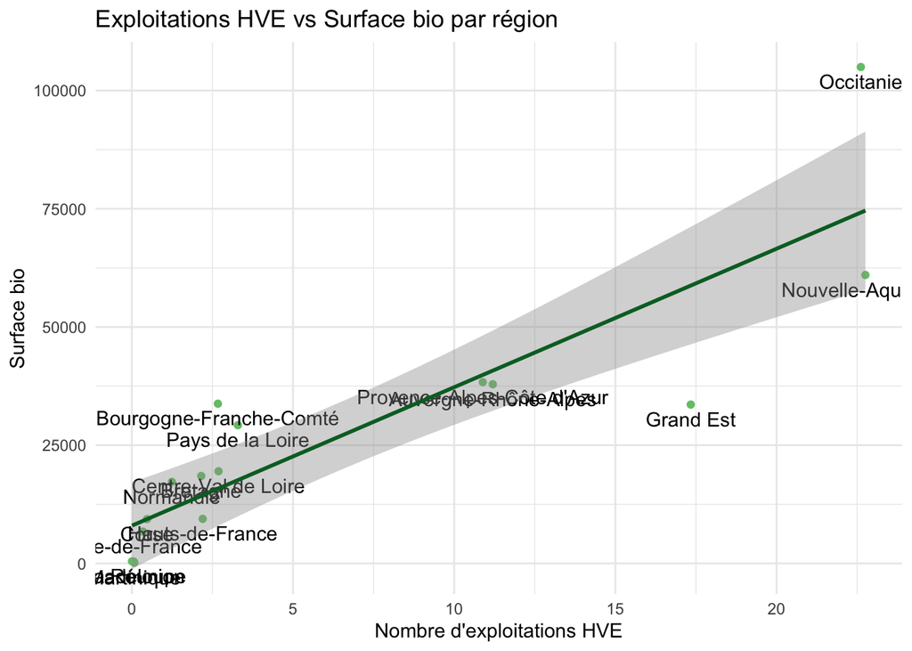

```r
#transforme les données pour pouvoir en faire des représentations
merged_data_long<-merged_data%>%
  pivot_longer(cols=c(nb_exp_hve, nb_exp_bio),
               names_to="Variable",
               values_to="Valeur")
#représentations graphiques hve et bio
ggplot(stats_bio_hve, aes(x = proportion_hve, y = moyenne_surf_bio, label = region)) +
  geom_point(color = "#74C476") +
  geom_text(vjust = 1.5, hjust = 0.5) +
  labs(x = "Nombre d'exploitations HVE", y = "Surface bio", title = "Exploitations HVE vs Surface bio par région") +
  theme_minimal()+
  geom_smooth(method="lm", color="#006D2C")
```

A l’aide de ce graphique nous pouvons remarquer qu’en effet, plus la surface agricole en bio augmente par région, plus le nombre d’exploitations HVE augmente également permettant d’affirmer que prendre ces indicateurs nous donnera des résultats similaires quant à une possible corrélation entre élections de conseillers régionaux écologistes et une agriculture durable dans la région.

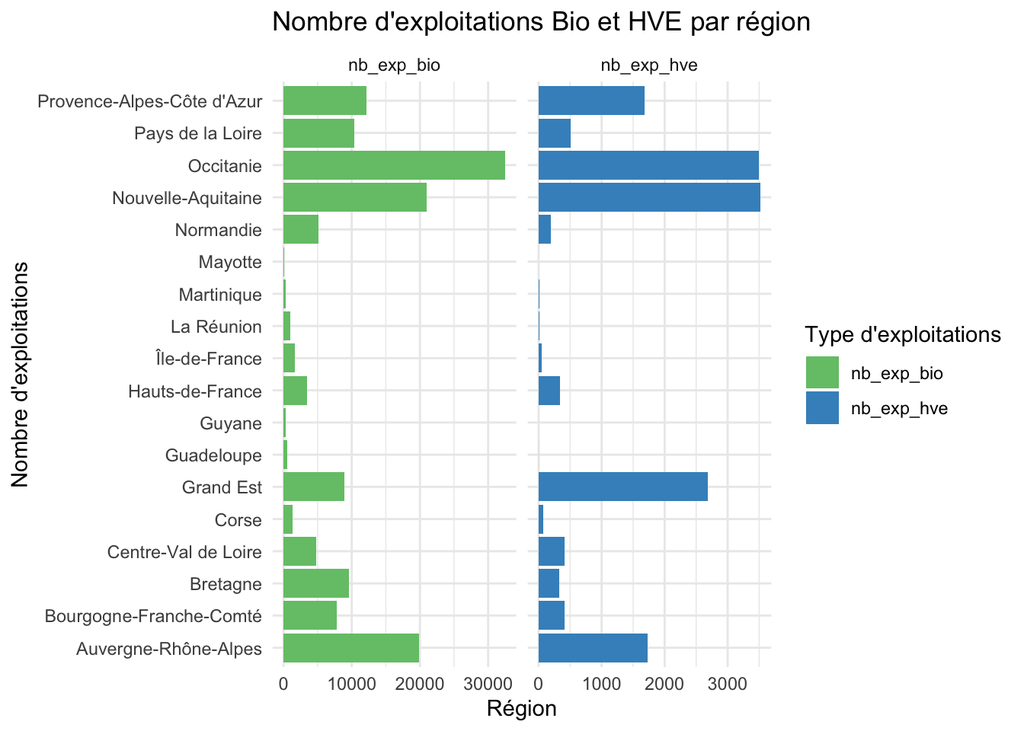

```r
ggplot(merged_data_long, aes(x =Valeur , y=region, fill=Variable)) +
  geom_bar(stat = "identity", position = "dodge") +
  scale_fill_manual(values=c("#74C476","#4292C6")) +
  labs(x = "Région", y = "Nombre d'exploitations", fill = "Type d'exploitations") +
  ggtitle("Nombre d'exploitations Bio et HVE par région") +
  theme(axis.text.x = element_text(angle = 45, hjust = 1)) +
  facet_wrap(~Variable, scales="free_x")+
  theme_minimal()
```

De même, on peut observer que les régions qui présentent le plus d’expolitations AB ont aussi un grand nombre d’exploitation HVE

```r
# Mettre les variables en format long
stats_bio_hve_long<-stats_bio_hve%>%
  pivot_longer(c(moyenne_surf_bio, moyenne_exp_bio, moyenne_exp_hve),
    names_to="Variable",
    values_to="Value")
#statistiques descriptives selon les variables nb exploitation hve  et bio et la variable surface bio
stats_distrib <- stats_bio_hve_long %>%
  group_by(Variable) %>%
  summarise(
    Min = min(Value, na.rm = TRUE),
    Q1 = quantile(Value, 0.25, na.rm = TRUE),
    Median = median(Value, na.rm = TRUE),
    Mean = mean(Value, na.rm = TRUE),
    Q3 = quantile(Value, 0.75, na.rm = TRUE),
    Max = max(Value, na.rm = TRUE))
kable(stats_distrib)
```

| Variable | Min | Q1 | Median | Mean | Q3 | Max |
| --- | --- | --- | --- | --- | --- | --- |
| moyenne_exp_bio | 78.00 | 1051.250 | 4966.50 | 7816.389 | 10146.75 | 32516.0 |
| moyenne_exp_hve | 1.00 | 68.000 | 376.50 | 966.750 | 1696.00 | 3520.0 |
| moyenne_surf_bio | 138.72 | 2023.158 | 17869.48 | 23389.457 | 33732.60 | 104972.2 |

Avec ces statistiques on remarque surtout qu’il y a de très grands écarts pour toutes les variables en comparant les min et les max de chacune des variables.

Pour expliquer ces grandes variations nous avons comparé la situation en métropole et dans les régions d’outres-mers.

```r
#création d'une base de données avec seulement les outres-mers
outres_mers<-merged_data%>%
  filter(region %in% c("Guadeloupe", "Martinique","Guyane","La Réunion","Mayotte"))%>%
  select(region,nb_exp_bio_ratio,nb_exp_hve_ratio,surfbio_sau_ratio,propor_siège)
#statistiques descriptives sur les outres-mers
outres_mers_stats<-outres_mers%>%
  summarise(moy_exp_bio=mean(nb_exp_bio_ratio, na.rm=T),
            moy_exp_hve=mean(nb_exp_hve_ratio, na.rm=T),
            moy_surfbio=mean(surfbio_sau_ratio, na.rm=T),
            moy_siège=mean(propor_siège, na.rm=T))
kable(outres_mers)
```

| region | nb_exp_bio_ratio | nb_exp_hve_ratio | surfbio_sau_ratio | propor_siège |
| --- | --- | --- | --- | --- |
| Guadeloupe | 6.851392 | 0.0137855 | 1.4209071 | 0 |
| La Réunion | 15.520535 | 0.1591850 | 0.9861244 | 0 |
| Martinique | 12.168720 | 0.4479283 | 0.7561087 | 0 |
| Guyane | 4.551387 | NA | 0.7406743 | 0 |
| Mayotte | 1.808905 | NA | 2.3275168 | NA |

Nous pouvons remarquer que les outres-mers ont de très faibles surfaces biologiques et presque pas d’exploitations certifiées HVE. De plus aucun élu régional ne provient d’une liste écologiste.

Les différences de ratio entre outres-mers et la métropole peuvent s’expliquer par les caractéristiques particulères de ces îles. Premièrement, les climats tropicaux favorisent la prolifération des parasites et des maladies, rendant l’agriculture biologique plus difficile. Ensuite, l’agriculture dans les outres-mers est orientée vers la culture de banane et de canne à sucre qui nécessitent des intrants chimiques pour maintenir des rendements élevés. Aussi nous pouvons noter la faible disponibilité et le coût élevé des intrants bio, décourageant la conversion à l’agriculture biologique. La demande locale pour les produits bio est également plus faible, ce qui diminue l’incitation économique à adopter ces pratiques et donc explique son faible développement dans ces régions comparées à la métropole.

Ainsi il apparaît comme pertinent de séparer nos analyses selon que les outres-mers sont pris en compte ou non.

```r
#de même, statistiques descriptives seulement pour les régions de métropole
metropole<-merged_data%>%
  filter(!(region %in% c("Guadeloupe", "Martinique","Guyane","La Réunion","Mayotte")))%>%
  select(nb_exp_bio_ratio,nb_exp_hve_ratio,surfbio_sau_ratio,propor_siège)

metropole_stats<-metropole%>%
  summarise(moy_exp_bio=mean(nb_exp_bio_ratio, na.rm=T),
                moy_exp_hve=mean(nb_exp_hve_ratio, na.rm=T),
                moy_surfbio=mean(surfbio_sau_ratio, na.rm=T),
                moy_siège=mean(propor_siège, na.rm=T))

kable(metropole_stats)
```

| moy_exp_bio | moy_exp_hve | moy_surfbio | moy_siège |
| --- | --- | --- | --- |
| 35.4992 | 3.32631 | 2.029425 | 21.2764 |

Nous pouvons clairement remarquer que le nombre d’exploitations certifiées AB est bien supérieur à celui du nombre d’exploitations certifiées HVE.

Le faible nombre de certification HVE s’explique premièrement parce que la certification est bien plus récente que celle AB. De plus, beaucoup des agriculteurs trouvent peu d’intérêts à se certifier HVE car cette certification ne permet pas de meilleurs débouchés à leur production, les consommateurs n’ayant pas connaissance de ce certificat. Enfin, la certification n’est pas mieux valorisée : elle ne mène pas à des subventions particulières ou encore à la vente de la production à un prix supérieur.

## IV- Représentations graphiques des données

Pour une meilleure compréhension des statistiques descriptives nous pouvons en faire quelques représentations graphiques.

Premièrement nous pouvons représenter la distribution du nombre d’exploitation biologiques et celui du nombre d’exploitation HVE pour pouvoir les comparer

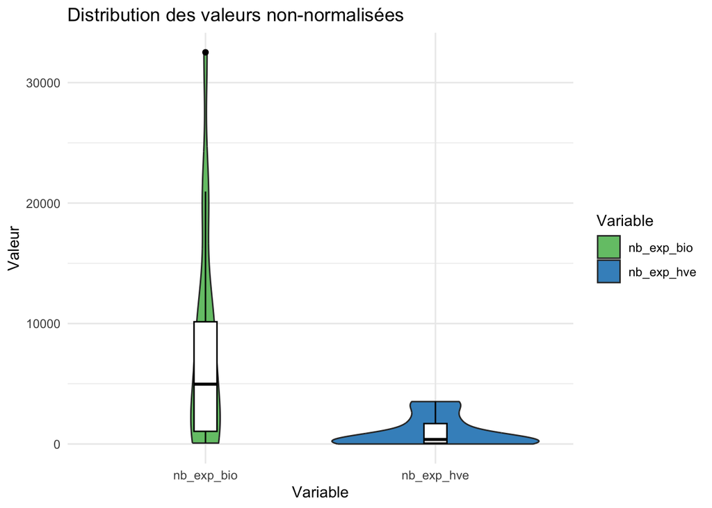

```r
#création violon pour représenter les données
ggplot(merged_data_long, aes(x = Variable, y = Valeur, fill = Variable)) +
  geom_violin() +
  geom_boxplot(width = 0.1, fill = "white", color = "black") +
  scale_fill_manual(values=c("#74C476","#4292C6"))+
  theme_minimal() +
  labs(x = "Variable",y = "Valeur",title = "Distribution des valeurs non-normalisées")
```

Nous remarquons que la distribution du nombre d’exploitations bio est très hétérogène avec une longue queue étirée vers le haut indiquant que la plupart des valeurs sont très faibles et la présence de quelques valeurs extrêmes.

Maintenant intéressons-nous au nombre de sièges étiquetés écologistes pour chacune des régions

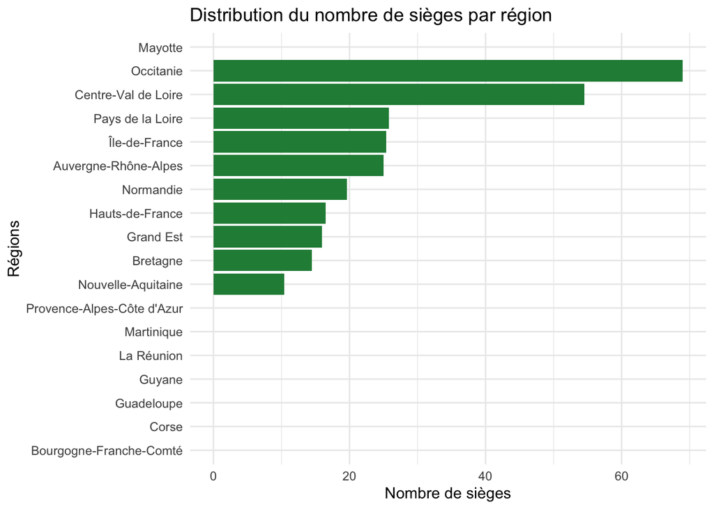

```r
#représentation graphique des résultats aux élections
ggplot(merged_data, aes(x=propor_siège, y=reorder(region, propor_siège))) +
  geom_histogram(stat="identity", fill= "#238B45") +
  theme_minimal() +
  labs(x = "Nombre de sièges",y = "Régions",title = "Distribution du nombre de sièges par région")
```

On remarque immédiatement que l’ensemble des outres-mers possède aucun élu au conseil régional étiqueté comme écologiste. Par la suite nous ne considèrerons plus les outres-mers étant donné que nous cherchons un lien entre le nombre d’élus écologistes et le développement d’une agriculture durable. De plus l’agriculture certifiée AB et HVE est très peu ou pas présente comme nous l’avons montré dans les statistiques descriptives. Il est donc incohérent d’essayer de chercher un lien.

Notre sujet portant sur une analyse régionale il nous paraît nécessaire de faire quelques cartes pour représenter nos données.

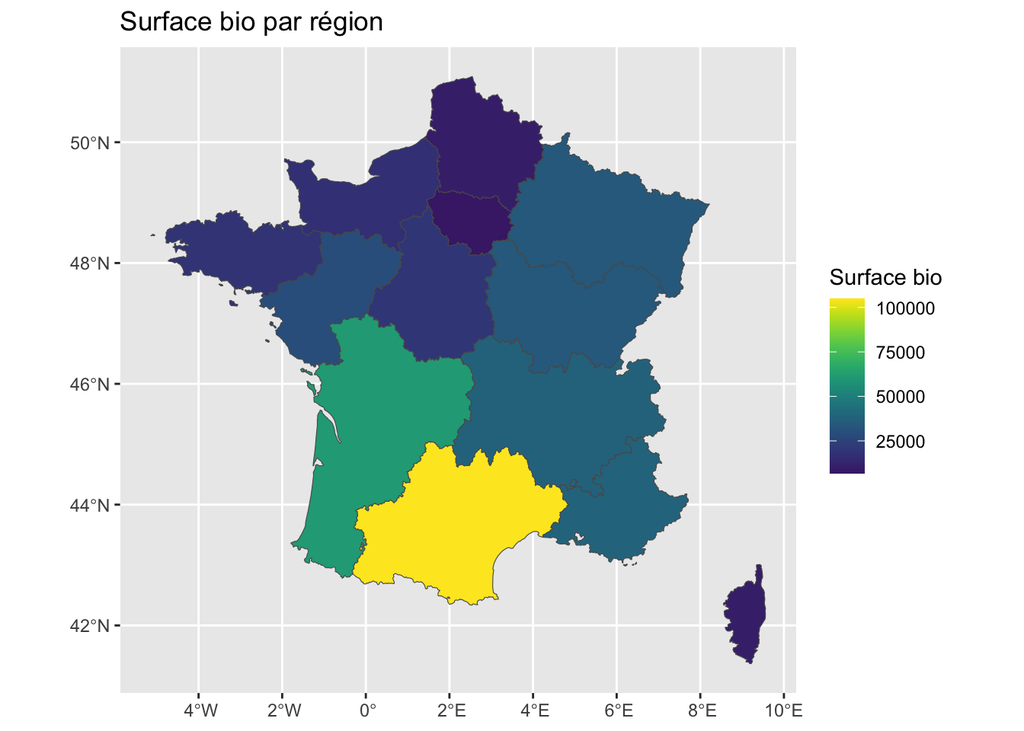

```r
#importer une base comprenant les données géographiques
region <- st_read(paste0(path,"regions-et-collectivites-doutre-mer-france/georef-france-region-millesime.shp"))
#filtrer les régions pour exclure les territoires d'outre-mer
region <- region %>%
  filter(!(reg_code %in% c("['01']","['02']","['03']","['04']","['06']")))%>%
  mutate(reg_code = gsub("\\['(\\d+)'\\]", "\\1", reg_code))

#fusionner les données spatiales des régions avec la base de données fusionnées
carte_data<-merge(region, merged_data, by.x = "reg_code", by.y = "coderegion", all.x = TRUE)

#créer la carte surface bio par région
ggplot(carte_data) +
  geom_sf(aes(fill = surfbio)) +
  scale_fill_viridis(option="D",name = "Surface bio", begin=0.1,end=1) +
  labs(title = "Surface bio par région")
```

On remarque une différence notable entre les régions du nord de la France et celles du sud pour que ce qu’il en est du développement de l’agriculture biologique.

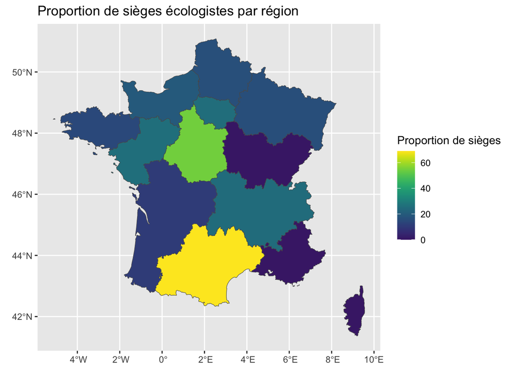

```r
#créer carte conseillers régionnaux écologistes par région
ggplot(carte_data) +
  geom_sf(aes(fill = propor_siège)) +
  scale_fill_viridis(option="D",name = "Proportion de sièges", begin=0.1,end=1)+
  labs(title="Proportion de sièges écologistes par région")
```

Pour ce qu’il en est des conseillers régionaux à tendance écologique, les résultats sont plus éparses entre les régions.

## V- Analyse de régressions

Afin de vérifier le lien entre nos différentes variables, nous allons faire plusieurs régressions linéaires.

L’équation de la première régression à estimer est :
$$\text{Nombre d'exploitation HVE}_r = \alpha_1 + \beta_1 \text{Proportion de sièges écologistes}_r + \varepsilon_r$$
L’équation de la deuxième régression à estimer est :
$$\text{Nombre d'exploitation bio}_r = \alpha_1 + \beta_1 \text{Proportion de sièges écologistes}_r + \varepsilon_r$$

```r
#régression linéaire
#on exclut les outres-mers de nos régressions
filtered_data<-merged_data %>%
  filter(!region %in% c("Guadeloupe", "Martinique", "Guyane", "La Réunion", "Mayotte"))

model1<-lm(nb_exp_hve~propor_siège,data=filtered_data)
model2<-lm(nb_exp_bio~propor_siège,data=filtered_data)
model3<-lm(surfbio~propor_siège,data=filtered_data)

#on cherche les p-values des différentes régressions
p_values_model1<-round(summary(model1)$coefficients[, 4],3)
p_values_model2<-round(summary(model2)$coefficients[, 4],3)
p_values_model3<-round(summary(model3)$coefficients[, 4],3)

stargazer(model1,model2,model3,type="text",
          se=list(NULL, NULL, NULL),
          add.lines=list(c("p-value",p_values_model1, p_values_model2,p_values_model3)),
          keep.stat=c("n", "rsq", "adj.rsq", "f"))
```

```
===========================================================
                                Dependent variable:
                         ----------------------------------
                         nb_exp_hve nb_exp_bio    surfbio
                            (1)         (2)         (3)
-----------------------------------------------------------
propor_siège               17.310     203.406    634.865*
                          (18.407)   (117.536)   (342.041)

Constant                  819.779   6,329.180*  18,769.490*
                         (532.913)  (3,402.817) (9,902.535)

-----------------------------------------------------------
p-value                    0.152       0.367       0.09
Observations                 13         13          13
R2                         0.074       0.214       0.238
Adjusted R2                -0.010      0.143       0.169
F Statistic (df = 1; 11)   0.884       2.995      3.445*
===========================================================
Note:                           *p<0.1; **p<0.05; ***p<0.01
```

Comme nous avons montré que la présence des outres-mers n’était pas pertinente dans le modèle, nous les avons exclus de la régression.

De plus, le nombre d’exploitations biologiques augmente de 203.406 quand la proportion de sièges écologistes augmente d’un point de pourcentage. La p-value est supérieur à 0.1 ce qui indique encore une fois que le coefficient n’est pas statistiquement significatif à un niveau de confiance de 90 %. On ne peut pas conclure quant à la dépendance de nos deux variables.

Aussi, lorsque le nombre de siège écologistes augmente d’un point de pourcentage, la surface agricole biologique augmente de 634 hectares dans la région, toute chose étant égale par ailleurs. En outre, on a une p-value de 0.1, signifiant que l’on peut rejeter à 90% que notre coefficient de régression ne soit pas nul. Donc pouvons donc affirmer qu’il y a une relation positive significative entre le nombre de siège écologiste et la surface biologique.

Pour avoir une idée plus précise de ce que représente une augmentation de 634 hectares, nous pouvons comparer cette valeur à la moyenne nationale de surface biologique qui est de 23 389. On aurait donc une hausse de 2,71% de la surface biologique ce qui n’est pas négligeable.

Voici une représentation de ces analyses de régression.

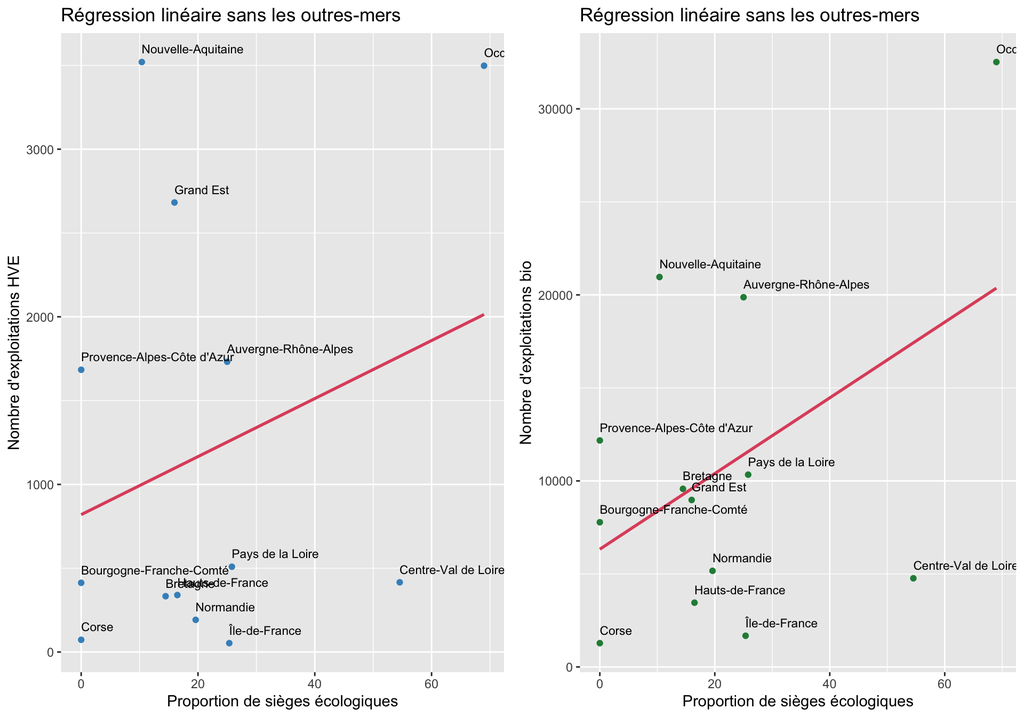

```r
#représentation graphique nombre d'exploitation hve
plot1<-ggplot(filtered_data, aes(x = propor_siège, y = nb_exp_hve)) +
  geom_point(color = "#4292C6") +
  geom_smooth(method = "lm", se = FALSE, color = "74C476") +
  geom_text(aes(label = region), color = "black", hjust =0, vjust = -1, size=3) +
  labs(x = "Proportion de sièges écologiques", y = "Nombre d'exploitations HVE",
       title = "Régression linéaire sans les outres-mers")

#représentation graphique nombre d'exploitation bio
plot2<-ggplot(filtered_data, aes(x = propor_siège, y = nb_exp_bio)) +
  geom_point(color = "#238B45") +
  geom_smooth(method = "lm", se = FALSE, color = "74C476") +
  geom_text(aes(label = region), color = "black", hjust = 0, vjust = -1, size=3) +
  labs(x = "Proportion de sièges écologiques", y = "Nombre d'exploitations bio",
       title = "Régression linéaire sans les outres-mers")

grid.arrange(plot1, plot2, ncol = 2)
```

## VI- Causalité

Il est donc difficile de conclure d’une parfaite relation entre le nombre de conseillers régionaux écologistes et le développement d’une agriculture durable même si certains liens peuvent quand même être faits. C’est le cas par exemple pour la région Occitanie où le nombre de conseillers régionaux écologistes est très important et le nombre de certifications AB et HVE également.

Cependant d’autres facteurs peuvent expliquer la relation de causalité entre les 2 variables.

Nous pouvons premièrement suggérer que la géologie du sol influence à la fois le type de culture cultivé et donc le nombre de certification AB ou HVE et aussi le type d’élus sur le territoire. Pour affirmer cela nous nous fondons sur l’étude *Tableau politique de la France de l’Ouest sous la Troisième République* publié par A. Siefried en 1913. Dans cette analyse empirique de sociologie électorale, l’auteur nous démontre qu’une terre de calcaire produit des votes à gauche tandis qu’une terre de granite des votes à droite. Nous pouvons appliquer cette logique à notre recherche en estimant que les conditions géologiques influencent à la fois le type de votes et le type d’agriculture. Il n’est pas possible de contrôler ces variables dans la régression au vu de notre modèle économétrique.

D’autres variables peuvent expliquer notre relation de causalité entre l’élection de députés écologistes et le nombre de certifications AB et HVE telles que :

o *Le niveau de diplôme* : la part de diplômé du supérieur

o *Le revenu* : la part de ménage imposé

o *L’emploi dans l’agriculture* : la part de PCS agriculteur

o *La densité de population urbaine*

o *La part de parcs nationaux*

o *Le nombre de catastrophe naturelle*

Nous allons donc maintenant utiliser ces variables pour tester la robustesse de notre modèle.

Par ailleurs il ne faut pas oublier les biais qui peuvent jouer dans la relation de causalité entre nos deux variables, notamment le biais des variables omises. En effet il se peut que des variables soient cachées dans la relation entre le nombre de sièges de conseillers régionaux à tendance écologique et le nombre de certification agricole et donc influence le coefficient de régression. Même si la relation de causalité est mise à l’épreuve par de nombreuses variables de contrôle, il se peut que certaines ne soient pas détectées.

De plus, le sens de la causalité peut être dans les 2 sens. Le nombre de certifications influence également le nombre de sièges écologistes dans la région. En effet nous pouvons émettre l’hypothèse que plus il y a d’exploitations agricoles, plus les agriculteurs voteront pour des conseillers régionaux écologistes qui leur permettront de développer leur activité.

## VII- Robustesse

Afin de vérifier la robustesse de nos résultats, nous avons commencé par comparer les coefficients à chaque fois qu’on exclut une des régions.

```r
regions<-unique(filtered_data$region)
models_list<-list()

#Boucle pour chaque région
for (i in regions) {
  region_data <- filtered_data %>% filter(region != i)
  model <- lm(nb_exp_hve ~ propor_siège, data = region_data)
  models_list[[i]] <- model
}
stargazer(models_list, type = "text")
```

```
=================================================================================================================================================================
                                                                                      Dependent variable:
                              -----------------------------------------------------------------------------------------------------------------------------------
                                                                                          nb_exp_hve
                                 (1)       (2)       (3)       (4)       (5)       (6)       (7)       (8)       (9)      (10)       (11)       (12)      (13)
-----------------------------------------------------------------------------------------------------------------------------------------------------------------
propor_siège                   16.923    15.236    16.213    30.054    13.503    19.138    16.512    18.378    16.961    23.402     -12.825    18.055    21.716
                              (19.205)  (20.217)  (19.092)  (20.544)  (19.958)  (17.888)  (19.021)  (18.504)  (18.780)  (15.423)   (23.436)   (19.022)  (19.832)

Constant                       787.940   901.480   905.173   696.304   969.767   647.943   900.832   897.900   907.855   474.592  1,217.461**  867.332   646.204
                              (561.869) (609.220) (569.767) (527.824) (601.406) (532.664) (565.993) (540.888) (555.831) (462.437)  (529.998)  (555.420) (597.600)

-----------------------------------------------------------------------------------------------------------------------------------------------------------------
Observations                     12        12        12        12        12        12        12        12        12        12         12         12        12
R2                              0.072     0.054     0.067     0.176     0.044     0.103     0.070     0.090     0.075     0.187      0.029      0.083     0.107
Adjusted R2                    -0.021    -0.041    -0.026     0.094    -0.052     0.013    -0.023    -0.001    -0.017     0.106     -0.068     -0.009     0.018
Residual Std. Error (df = 10) 1,357.503 1,359.383 1,344.747 1,268.479 1,341.948 1,262.435 1,343.166 1,307.565 1,329.056 1,077.701  1,182.392  1,343.635 1,333.456
F Statistic (df = 1; 10)        0.776     0.568     0.721     2.140     0.458     1.145     0.754     0.986     0.816     2.302      0.299      0.901     1.199
=================================================================================================================================================================
Note:                                                                                                                                 *p<0.1; **p<0.05; ***p<0.01
```

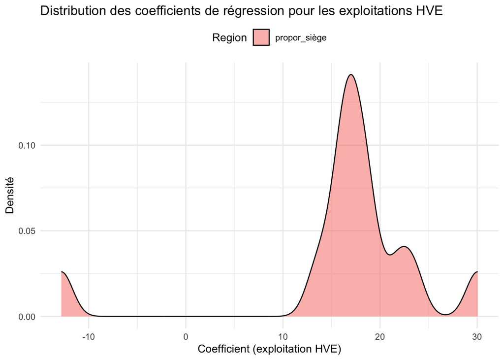

```r
coefficients_df<-lapply(models_list, function(model) coef(model)[2])
coefficients_df<-do.call(rbind, coefficients_df)
coefficients_data<-data.frame(
  Coefficient=as.vector(coefficients_df),
  Region=rep(colnames(coefficients_df), each=nrow(coefficients_df)))

#Créer un graphique de densité des coefficients
ggplot(coefficients_data, aes(x =Coefficient, fill=Region)) +
  geom_density(alpha=0.5) +
  labs(title="Distribution des coefficients de régression pour les exploitations HVE",
       x ="Coefficient (exploitation HVE)", y ="Densité") +
  theme_minimal() +
  theme(legend.position="top")
```

Nous avons ensuite fait de même avec les exploitations biologiques.

```r
models_list2<-list()
#Boucle pour chaque région
for (i in regions) {
  region_data<-filtered_data %>% filter(region!=i)
  model<-lm(nb_exp_bio~propor_siège,data=region_data)
  models_list2[[i]]<-model
}

stargazer(models_list2, type="text")
```

```
==========================================================================================================================================================================================
                                                                                                  Dependent variable:
                              ------------------------------------------------------------------------------------------------------------------------------------------------------------
                                                                                                       nb_exp_bio
                                  (1)         (2)         (3)         (4)         (5)         (6)         (7)         (8)         (9)        (10)         (11)        (12)        (13)
------------------------------------------------------------------------------------------------------------------------------------------------------------------------------------------
propor_siège                    196.576     210.803     203.861    323.073**    177.664     202.711     196.907    212.095*     201.547    233.664*     -43.403      204.627    233.215*
                               (116.985)   (129.571)   (123.888)   (118.282)   (127.151)   (123.616)   (120.110)   (114.698)   (120.959)   (109.670)   (132.437)    (123.411)   (126.240)

Constant                       5,767.406   6,037.788   6,293.725   5,169.689  7,343.289*   6,394.511  6,988.755*  6,964.790*  6,798.200*   4,614.683  9,586.221***  6,407.108   5,154.868
                              (3,422.567) (3,904.422) (3,697.210) (3,038.927) (3,831.500) (3,681.108) (3,573.999) (3,352.695) (3,580.042) (3,288.356) (2,995.021)  (3,603.363) (3,804.047)

------------------------------------------------------------------------------------------------------------------------------------------------------------------------------------------
Observations                      12          12          12          12          12          12          12          12          12          12           12          12          12
R2                               0.220       0.209       0.213       0.427       0.163       0.212       0.212       0.255       0.217       0.312       0.011        0.216       0.254
Adjusted R2                      0.142       0.130       0.134       0.370       0.080       0.133       0.133       0.180       0.139       0.243       -0.088       0.137       0.180
Residual Std. Error (df = 10)  8,269.090   8,712.140   8,726.047   7,303.213   8,549.426   8,724.365   8,481.505   8,104.949   8,560.290   7,663.461   6,681.698    8,717.022   8,488.170
F Statistic (df = 1; 10)         2.824       2.647       2.708      7.460**      1.952       2.689       2.688      3.419*       2.776      4.539*       0.107        2.749      3.413*
==========================================================================================================================================================================================
Note:                                                                                                                                                          *p<0.1; **p<0.05; ***p<0.01
```

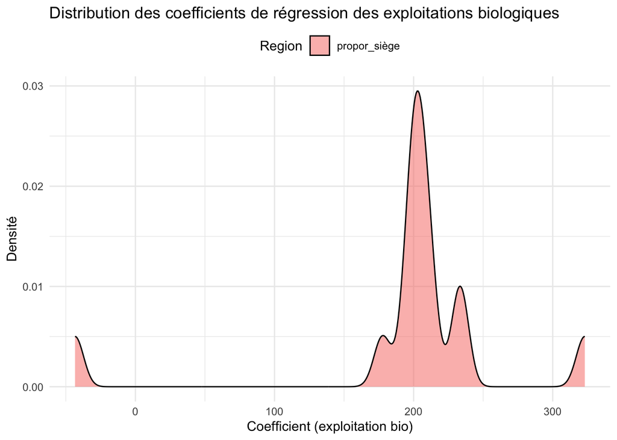

```r
coefficients_df2<-lapply(models_list2, function(model) coef(model)[2])
coefficients_df2<-do.call(rbind, coefficients_df2)
coefficients_data2<-data.frame(
  Coefficient=as.vector(coefficients_df2),
  Region=rep(colnames(coefficients_df2), each=nrow(coefficients_df2)))

#Créer un graphique de densité des coefficients
ggplot(coefficients_data2, aes(x=Coefficient, fill=Region)) +
  geom_density(alpha=0.5) +
  labs(title="Distribution des coefficients de régression des exploitations biologiques",
       x="Coefficient (exploitation bio)", y="Densité") +
  theme_minimal() +
  theme(legend.position="top")
```

On remarque que les coefficients sont majoritairement autour de 200. On observe des données extrêmes lorsqu’on retire l’Occitanie (11), avec un coefficient de -43.403 ou quand on enlève le Centre Val de Loire (4) avec un coefficient de 323.073. Certains coefficients sont significatifs au niveau de confiance de 90% comme celui associé à l’absence de l’Ile de France, de la Nouvelle Aquitaine et de la Provence Alpes Côtes d’Azur. Le coefficient le plus fréquent étant proche de celui trouvé dans notre régression initiale, on peut considérer que notre régression était représentative de la réalité. Cependant la p-valeur reste trop faible pour faire des conclusions définitives.

Nous allons donc maintenant tester la robustesse de notre modèle grâce aux variables de contrôles mentionnées dans la partie causalité.

Premièrement nous importons les bases de données nécessaires contenant nos variables que nous souhaitons tester. Ensuite il nous suffit d’agréger ces bases de données à notre base de données générale après avoir sélectionner ce qui nous intéresse dans les bases annexes.

```r
#ajout nombre d'arrêtés catastrophe naturelles par région
cata_naturelle<-read_excel(paste0(path,"gaspar.xlsx"), sheet="Data", skip=4)
cata_naturelle<-cata_naturelle%>%
  filter(an=="2023")

merged_data<-merged_data%>%
  left_join(cata_naturelle, by = c("coderegion" = "codgeo"))

#ajout part de parc Natura 2000 par région
natura<-read_excel(paste0(path,"natura2000.xlsx"), sheet="Data", skip=4)
#on a les données par département que je cherche maintenant à regrouper par région
rég_dép<-read.csv(paste0(path,"departements-region.csv"))

merged_natura<-merge(natura, rég_dép,by.x="codgeo", by.y="num_dep")

merged_natura<-merged_natura %>%
  group_by(region_name)%>%
  summarise(part_parc_nat=sum(as.numeric(natura2000))) #pb : sommer des pourcentages

merged_data<-merged_data%>%
  left_join(merged_natura, by = c("libgeo" = "region_name"))

#ajout base de données densité de population
densite_pop<-read_excel(paste0(path,"densité-pop.xlsx"),skip=4)
#on ne garde que le dernier rescensement
densite_pop<-densite_pop%>%
  filter(an==2020)%>%
  select(-an, -libgeo)

merged_data<-merged_data%>%
  left_join(densite_pop, by = c("coderegion" = "codgeo"))

#ajout base de données sur la part des ménages fiscaux imposés
menage_fiscal<-read_excel(paste0(path,"ménages-fiscaux-imposés.xlsx"),skip=4)

menage_fiscal<-menage_fiscal %>%
  select(-an, -libgeo)

merged_data<-merged_data%>%
  left_join(menage_fiscal, by = c("coderegion" = "codgeo"))

#ajout base de données sur la part d'agriculteurs dans la région
part_agriculteur<-read_excel(paste0(path,"part-agriculteurs.xlsx"),skip=4)

part_agriculteur<-part_agriculteur%>%
  filter(an==2020,sexe=="T") %>%
  select(-an, -libgeo, -sexe)

merged_data<-merged_data%>%
  left_join(part_agriculteur, by = c("coderegion" = "codgeo"))

#Ajout base de donnée sur la part de diplomés du supérieur
dipl_sup<-read_excel(paste0(path,"part-dilpômés-sup.xlsx"),skip=4)

dipl_sup<-dipl_sup%>%
  filter(an==2020,sexe=="T")%>%
  select(-an, -libgeo, -sexe)

merged_data<-merged_data%>%
  left_join(dipl_sup, by = c("coderegion" = "codgeo"))

#de même on enlève les outre-mers pour faire nos régressions
filtered_data_caus<- merged_data %>%
  filter(!region %in% c("Guadeloupe", "Martinique", "Guyane", "La Réunion", "Mayotte"))

#coefficients de régression
list(lm(nb_exp_bio ~ propor_siège, filtered_data_caus),
     lm(nb_exp_bio ~ propor_siège+ nb_catnat, filtered_data_caus),
     lm(nb_exp_bio ~ propor_siège+ nb_catnat + part_parc_nat, filtered_data_caus),
     lm(nb_exp_bio ~ propor_siège+ nb_catnat + part_parc_nat+ log(dens_pop), filtered_data_caus),
     lm(nb_exp_bio ~ propor_siège+ nb_catnat + part_parc_nat+ log(dens_pop)+ pt_menimp, filtered_data_caus),
     lm(nb_exp_bio ~ propor_siège+ nb_catnat + part_parc_nat+ log(dens_pop)+ pt_menimp+ p_csp_agr, filtered_data_caus),
     lm(nb_exp_bio ~ propor_siège+ nb_catnat + part_parc_nat+ log(dens_pop)+ pt_menimp+ p_csp_agr+ p_diplsup15, filtered_data_caus)) %>% stargazer(type="text")
```

```
=======================================================================================================================================================================
                                                                                    Dependent variable:
                    ---------------------------------------------------------------------------------------------------------------------------------------------------
                                                                                        nb_exp_bio
                            (1)                  (2)                    (3)                  (4)                  (5)                 (6)                  (7)
-----------------------------------------------------------------------------------------------------------------------------------------------------------------------
propor_siège              203.406               88.714                53.959                56.679              53.221               7.284               -1.886
                         (117.536)             (85.948)              (74.873)              (80.179)            (83.945)            (70.556)             (40.160)

nb_catnat                                      0.509***               0.332**               0.330*               0.302               0.156                0.168
                                               (0.138)                (0.142)              (0.151)              (0.165)             (0.148)              (0.084)

part_parc_nat                                                         57.515*              56.222*              60.294*            86.156**             57.388**
                                                                     (26.260)              (28.409)            (30.490)            (27.150)             (17.285)

log(dens_pop)                                                                              -424.313            1,001.370           6,303.005             961.030
                                                                                         (1,964.589)          (3,204.668)         (3,522.740)          (2,470.745)

pt_menimp                                                                                                      -331.219            -370.412           -1,340.349**
                                                                                                               (571.939)           (459.603)            (370.662)

p_csp_agr                                                                                                                         14,490.540*          10,074.670*
                                                                                                                                  (6,575.543)          (3,922.858)

p_diplsup15                                                                                                                                            1,397.424**
                                                                                                                                                        (379.049)

Constant                6,329.180*             -552.851             -1,803.325             298.400            10,205.490          -24,248.290          14,041.560
                        (3,402.817)          (2,975.332)            (2,596.582)          (10,111.130)        (20,103.630)        (22,472.920)         (16,457.790)

-----------------------------------------------------------------------------------------------------------------------------------------------------------------------
Observations                13                    13                    13                    13                  13                  13                   13
R2                         0.214                0.668                  0.783                0.785                0.794               0.886                0.969
Adjusted R2                0.143                0.601                  0.711                0.677                0.647               0.773                0.927
Residual Std. Error 8,320.520 (df = 11)  5,673.844 (df = 10)    4,830.402 (df = 9)    5,108.543 (df = 8)  5,334.956 (df = 7)  4,283.896 (df = 6)   2,433.650 (df = 5)
F Statistic         2.995 (df = 1; 11)  10.048*** (df = 2; 10) 10.842*** (df = 3; 9) 7.281*** (df = 4; 8) 5.408** (df = 5; 7) 7.799** (df = 6; 6) 22.656*** (df = 7; 5)
=======================================================================================================================================================================
Note:                                                                                                                                       *p<0.1; **p<0.05; ***p<0.01
```

On remarque que le coefficient associé à la proportion de siège varie beaucoup en fonction des variables de contrôle et qu’il n’est pas significatif au niveau de confiance de 95%. Cela signifie que la relation entre la proportion de sièges écologiques et le nombre d’exploitation bio n’est pas robuste à l’inclusion de ces variables.

o *Le nombre de catastrophe naturelle* : On suppose que plus il y a de catastrophes naturelles dans la région, plus les populations sont sensibilisées au changement climatique et donc ils souhaiteront voter pour des conseillers qui défendent l’environnement et aussi consommer de manière plus responsable donc avec des produits agricoles certifiés. Pour cela nous prenons le nombre d’avis de catastrophe naturelle publiées par la région. Cette relation de causalité est vérifiée statistiquement. En effet, une hausse d’un point dans le nombre de catastrophes naturelles est associée à un hause de 0,5 exploitations AB, toute chose étant égale par ailleurs. Et ce coefficient est significatif à un seuil de 5%.

De même, on suppose que plus il y a de parcs naturels dans la région, plus les personnes sont sensibilisées enclenchant le même mécanisme que précédemment. On observe une hausse d’un point dans la part de parc naturel est associée à une hausse de 57 exploitations AB avec une p-valeur inférieure à 10% signifiant que l’on peut rejeter l’hypothèse que notre coefficient est nul avec 10% de risque de se tromper.

## VIII- Hétérogénéité

Afin de vérifier si le lien entre surface HVE ou bio et la proportion de sièges écologistes varie d’une région à l’autre, nous avons utilisé comme variable de contrôle le niveau de précipitations par région.

```r
#ajout d'une base de données sur le niveau de précipitation par région en 2022
pluie<-read_excel(paste0(path,"precipitation2022.xlsx"))
pluie$`Code Région` <- as.character(pluie$`Code Région`)
filtered_data<-filtered_data%>%
  left_join(pluie, by = c("coderegion" = "Code Région"))

#modèles de régression
model3<-lm(nb_exp_hve ~ propor_siège + Précipitation, data = filtered_data)
model4<-lm(nb_exp_hve ~ propor_siège + Précipitation + propor_siège*Précipitation, data = filtered_data)
model5<-lm(nb_exp_hve ~ propor_siège + dens_pop + propor_siège*dens_pop, data = filtered_data_caus)

stargazer(model1, model3, model4, model5, type="text")
```

```
========================================================================================================
                                                        Dependent variable:
                           -----------------------------------------------------------------------------
                                                            nb_exp_hve
                                   (1)                 (2)                (3)                (4)
--------------------------------------------------------------------------------------------------------
propor_siège                     17.310              17.208             -190.446            30.023
                                (18.407)            (19.220)           (246.035)           (47.759)

Précipitation                                         1.352              -1.591
                                                     (4.443)            (5.691)

propor_siège:Précipitation                                               0.358
                                                                        (0.423)

dens_pop                                                                                    2.242
                                                                                           (13.511)

propor_siège:dens_pop                                                                       -0.146
                                                                                           (0.533)

Constant                         819.779              1.540            1,569.406           728.704
                                (532.913)          (2,746.270)        (3,345.293)        (1,339.490)

--------------------------------------------------------------------------------------------------------
Observations                       13                  13                  13                 13
R2                                0.074               0.083              0.151              0.164
Adjusted R2                      -0.010              -0.101              -0.133             -0.114
Residual Std. Error        1,303.071 (df = 11) 1,360.390 (df = 10) 1,380.069 (df = 9) 1,368.876 (df = 9)
F Statistic                0.884 (df = 1; 11)  0.452 (df = 2; 10)  0.532 (df = 3; 9)  0.590 (df = 3; 9)
========================================================================================================
Note:                                                                        *p<0.1; **p<0.05; ***p<0.01
```

On observe que l’augmentation de 1mm de précipitation annuelle est associée à une augmentation de 1,3 exploitation HVE dans la région, toute chose étant égale par ailleurs. Aussi on a le coefficient d’interaction qui signifie qu’une une variation de 1mm de précipitations annuelles augmente l’effet de 0,4 points de pourcentage le nombre d’exploitations HVE dans la région. Donc dans les régions où il y a une plus forte précipitation, l’impact du nombre de sièges écologiste est plus fort sur le nombre d’exploitations HVE que sur les régions avec de faibles précipitations.

De même, lorsque la densité de population augmente d’un habitant au kilomètre carré, l’effet du nombre de sièges écologistes sur le nombre d’exploitations HVE diminue de 0.14 exploitation certifiée. Autrement dit, dans les régions où la densité de population est plus élevée, l’impact du nombre de sièges écologistes sur le nombre d’exploitations HVE est moindre que dans les régions où la densité de population est plus faible.

Dans les 2 cas les coefficients ne sont pas significatifs, donc on ne peut ni affirmer ni infirmer que les caractéristiques des régions jouent dans la relation de causalité. Peut-être d’autres caractéristiques des régions expliquent les différences d’effets du nombre de sièges écologistes sur le nombre de certification, sinon comment expliquer des valeurs extrêmement différentes pour la région Occitanie par exemple. On peut supposer que des raisons historiques expliquent ce lien.

Par ailleurs, nous n’avons pas inclus les outres-mers dans les tests d’hétérogénéité car ces régions ne possèdent pas de conseillers écologistes et très peu, voire pas, de certification. Toute de même on peut affirmer une hétérogénéité entre les régions des outres-mers et celles de métropole

## IX- Conclusions

Cependant nous pouvons noter que les dernières élections régionales ont eu lieu en 2021 et que nos bases de données sur le nombre d’exploitation AB et HVE datent de 2022. Il est donc peut-être trop tôt pour analyser l’effet des élections sur les politiques publiques mises en place. D’ici les prochaines élections en 2028, il serait judicieux de reconduire cette enquête afin de conclure sur une réelle influence des conseillers régionaux écologistes sur les politiques publiques mises en place.

## X- Sources

Léa Sénégas ,*Quand l’alimentation se fait politique(s)*, 2020

Sabine Girard et Pierre Antoine Landel, « Du développement durable à la transition écologique : gouverner le changement territorial », *Géographie, Economie et Société*, 2023